# How to use IRTnorm

Hannah M. Heister, Casper J. Albers and Marieke E. Timmerman

2026-10-19

# Introduction

Norm-referenced psychological tests evaluate an individual’s performance relative to a reference population, typically using standardized scores such as T-, IQ- or z-scores (American Educational Research Association (2014)). Many developmental and intelligence tests rely on reference populations that change continuously with age.

In such settings, item response theory (IRT)-based continuous norming models are useful for deriving age-specific norm information. These models explicitly allow the latent trait distribution to depend on age. As a result, each individual’s latent trait estimate can be directly compared to the age-specific reference population using a z-standardized norm score (Heister et al. (2024)). As in most parametric IRT models, the latent trait distribution is assumed to be normally distributed in the reference population. Further, the latent trait distribution of psychological tests can typically be assumed to change smoothly with age. Therefore, the age-related changes can be captured by modeling the distribution’s mean and standard deviation as a smooth function of age, using polynomial regression or penalized splines.

Simulation studies have demonstrated that IRT-based continuous norming models can accurately recover age-specific norms, and empirical evaluation of IDS-2 (Grob et al. (2018)) has shown that these models can fit empirical data well (Heister et al. (2024)). Compared to raw score–based continuous norming methods, which is the default approach in many applications, IRT-based models offer several advantages. These include the use of all available item-level information, the ability to model multiple latent traits and their relationships, and the straightforward integration of adaptive testing procedures.

`IRTnorm` is based on a framework for deriving age-specific norm scores using Bayesian IRT-based continuous norming models. It includes tools for model comparison, model estimation, visual inspection of model fit, and extraction of norm scores.

This vignette introduces the main modeling concepts of `IRTnorm` and demonstrates its use on example data.

# Workflow overview

The main workflow in `IRTnorm` consists of:

1. Perform model selection (`compare_IRTnorm_models`,`compare_age_models`, `visual_age_models`);
2. Fit the selected model and extract all important model information (`estimate_norming_model`);
3. Evaluate model fit (`raw_score_ppc`, `visual_raw_score_ppc`, `item_person_fit`, `item_residual_cor`, `quantile_curves`,`normscore_dist`, `effect_age`, and for hierarchical models additionally `cor_structure`)
4. Norm new individuals (`norm_new_individual`).

# Norming a unidimensional test

We illustrate the modeling process using a small simulated data set (response_data), to keep the example concise. In practical applications, larger data sets may be required.

The following code loads the required package and the example data.

```r
library(IRTnorm)
library(ggplot2)
data("response_data")
```

## 1. Perform model selection

Selecting an appropriate IRT-based norming model for a normative dataset requires considering a set of plausible models. The models in this set can differ in both the specific IRT model choice, and/or the model specifications for the age effects.

When selecting candidate IRT models, a pre-selection should be made based on the characteristics of the test. For example, if the test contains binary items and guessing might influence responses, a 3PL-norm model may be evaluated alongside the 2PL-norm model. If guessing is unlikely, only 1PL- and 2PL-norm models need to be considered.

To compare the fit of the plausible IRT models, the function `compare_IRTnorm_models()` can be used. This function fits the set of plausible models specified and returns their expected log predictive density (ELPD) differences for comparison, relying heavily on the `loo` package, see Vehtari et al. (2026).

The IRT models to compare are specified using the `model_specifications` argument. This argument expects a list in which each element holds the model information for one norming model. Each element itself is a list containing at minimum the `irt_model` argument, which specifies the IRT model to be fitted, and the `age_model` argument, which specifies whether age effects are modeled using splines or polynomial regression. Additional configuration options are available depending on the value of the argument `age_model`. See the function documentation for a complete description of the available options.

To ensure a fair comparison, we recommend using the same polynomial degrees across all models and choosing degrees that are sufficiently high to capture the underlying trajectory. In this example, we use a fourth-degree polynomial for the mean and a third-degree polynomial for the standard deviation. This function uses 500 warm-up and 500 sampling iterations by default to keep the computational cost minimal. However, increasing the number of iterations can be useful for complex model comparison or to increase precision. For this illustration we use the default number of iterations. Finally, the norming data must be supplied via the data argument as either a `data.frame` or a `matrix` containing the individuals’ ages and item responses. The age variable (`age_variable`) and the item response variables (`item_variables`) can be specified either by their variable names or by their column positions.

```r
 model_list <- list( A = list(irt_model = "1PLnorm", age_model = "poly",
                                        poly_mean = 4, poly_sd = 3),
                     B = list(irt_model = "2PLnorm", age_model = "poly",
                                        poly_mean = 4, poly_sd = 3))

IRTmods <- compare_IRTnorm_models(model_specifications = model_list,
                                              raw_data = response_data,
                                              age_variable = "age",
                                              item_variables = 1:50)
```

Before evaluating the ELPD differences between the models, we are going checking whether the LOO approximation was stable by checking Pareto k values.

```r
sum(IRTmods[[2]]$pareto_k > 0.7)
```

```
#> [1] 0
```

All Pareto k values are below 0.7, indicating the LOO approximation is stable enough to rely on the ELPD difference for model selection.

[output not shown]

We recommend selecting the more complex IRT model only if the ratio ELPD_diff / SE is less than -1.96 for the comparison with the less complex model. In this example, this criterion is met, and we therefore select the 2PL norming model for the remainder of the analysis.

Once the IRT model has been selected, the next step is to determine the most appropriate specification for the age effect. The function `compare_age_models()` compares models based on their expected log predictive density (ELPD), either over a user-specified grid of polynomial degrees or by using forward selection. We recommend using forward selection, as this can be more efficient than a grid search. It is often also informative to compare polynomial regression with penalized splines, which can be done by setting `include_splines = TRUE`.

```r
agemodel_2PL <- compare_age_models(method = "forward",
                                   irt_model = "2PLnorm",
                                   raw_data = response_data,
                                   age_variable = "age",
                                   item_variables = 1:50,
                                   include_splines = TRUE)
```

To check it the LOO approximation was stable, we again check pareto k

```r
colSums(agemodel_2PL$paretok > 0.7)
```

```
#>  [1] 0 0 0 0 0 1 1 0 0 0 0 0
```

This shows that two of the evaluated models had a pareto k value above the 0.7 threshold.

To check whether these points have an influence on the model selection we rerun the forward selection with omitting the two influential points. To do so, we first identify the influential points as excl and then create a new dataset response_data_excl which sets the two influential points as missing values.

```r
temp <- data_prep(raw_data = response_data,
                  age_variable = "age",
                  item_variables = 1:50,
                  age_model = "splines")

excl <- NULL
for(i in 1:ncol(agemodel_2PL$paretok)){
  excl <- c(excl, which(agemodel_2PL$paretok[,i] > 0.7))
}
excl <- unique(excl)

response_data_excl <- response_data
for(ex in excl){
  response_data_excl[ temp$jj[ex],temp$ii[ex] +1] <- NA
}
agemodel_2PL_excl <- compare_age_models(method = "forward",
                                   irt_model = "2PLnorm",
                                   raw_data = response_data_excl,
                                   age_variable = "age",
                                   item_variables = 1:50,
                                   include_splines = TRUE)
```

```r
colSums(agemodel_2PL_excl$paretok > 0.7)
```

```
#>  [1] 0 0 0 0 0 0 0 0 0 0 0 0
```

In this case, when excluding the two influential points for the full data there are no highly influential points anymore. This however, is not always the case therefore our aim here is to check how much the different data sets influence the model selection.

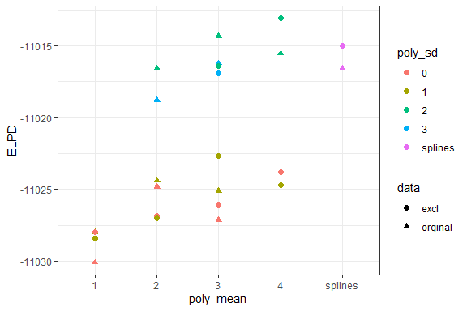

```r
combi <- cbind(rbind(agemodel_2PL$best_model, agemodel_2PL_excl$best_model),
               data = c(rep("orginal",nrow(agemodel_2PL$best_model)),
                        rep("excl",nrow(agemodel_2PL_excl$best_model))))
combi$poly_mean[is.na(combi$poly_mean)] <- "splines"
combi$poly_sd[is.na(combi$poly_sd)] <- "splines"

ggplot(combi) + geom_point(aes(poly_mean, ELPD, shape = data, color =poly_sd), size = 2) +
  theme_bw()
```

This shows that while the magnitude of the ELPD differs slightly between the two data sets, the general pattern remains the same. It seems as if the secound order polynomial for the standard deviation is the best. Only for the mean there is a small discrepancies, while the original data favors the third polynomial, the data with excluded points favors the forth.

However, because these are very small differences in performance, we argue the selection should not only be based on the ELPD, but also on the resulting trajectory.

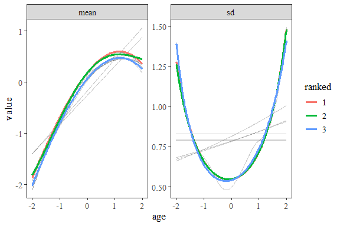

```r
 visual_age_models(agemodel_2PL, perspective = "trajectory", highlight_ranks = 3)
```

Based on this trajectory, we select the model with the the second best ELPD rank. We have strong theoretical believe that the latent trait mean does not decrease strongly for older individuals, and therefore select the mean trajectory that keeps the trajectory as stable as possible for these individuals. Looking at the ELPD differences of the full data, this is the model with forth polynomial for the mean and secound for the standard deviation.

```
#> Ignoring unknown labels:
#> • shape : "rank"
```

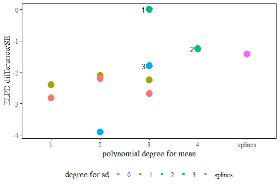

```r
visual_age_models(agemodel_2PL, perspective = "ELPD", highlight_ranks = 3)
```

## 2. Fit the selected model and extract all important model information

Once the norming model has been selected, it should be refitted using a sufficient number of iterations to obtain the final parameter estimates. The resulting model can then be used to extract all information required for norming. This is accomplished with the `estimate_norming_model()` function.

```r
info <- estimate_norming_model(raw_data = response_data,
                               age_variable = "age",
                               item_variables = 1:50,
                               irt_model  = "2PLnorm",
                               age_model = "poly",
                               poly_mean = 4,
                               poly_sd = 2,
                               seed = 1234,
                               iter_warmup = 2000,
                               iter_sampling =2000,
                               extract_stan_object = TRUE)
```

After fitting the IRT norming model, its convergence and overall fit should be evaluated to assess whether the resulting estimates are trustworthy. The `IRTnorm` package provides several functions for assessing and visualizing model fit from different perspectives.

The first step in evaluating a Bayesian IRT norming model is to verify that the MCMC algorithm has converged, as reliable inference depends on convergence. For this the model should have no divergent transitions which can be checked with

```r
sum(info$model_stan_obj$sampler_diagnostics()[,,"divergent__"])
```

[output not shown]

Two key diagnostics are the potential scale reduction factor (R-hat) and the effective sample size (ESS). Values of R-hat should be close to 1, indicating convergence across chains, while larger ESS values indicate more precise and reliable parameter estimates.

```r
info$conv_info
```

```
#>    diagnostic variable         Min.      1st Qu.       Median         Mean
#> 1        rhat  z_theta    0.9996654     1.000185     1.000508     1.000593
#> 2        rhat p1_theta    1.0001329     1.000598     1.001736     1.002732
#> 3        rhat p2_theta    1.0009534     1.001187     1.001421     1.001987
#> 4        rhat    alpha    0.9999813     1.000361     1.000533     1.000661
#> 5        rhat     beta    1.0008476     1.002377     1.004243     1.004141
#> 6    ess_bulk  z_theta 3673.6692858 11693.270638 13862.864217 12780.782894
#> 7    ess_bulk p1_theta  673.7645581  1957.398325  2265.819149  2029.973189
#> 8    ess_bulk p2_theta 2262.4614992  2555.985095  2849.508691  2718.608270
#> 9    ess_bulk    alpha 3992.4169491  5831.177571  6389.001970  6339.181713
#> 10   ess_bulk     beta  666.2113183   753.971224   943.526517  1170.849857
#> 11   ess_tail  z_theta 4134.7031409  5478.672064  5719.767606  5698.072666
#> 12   ess_tail p1_theta 1206.5841758  2811.799389  3638.894017  3151.992843
#> 13   ess_tail p2_theta 4113.2943029  4404.226769  4695.159235  4596.552030
#> 14   ess_tail    alpha 4133.2040104  5311.086068  5596.374923  5592.931996
```

[output cut: 17 more lines]

In this example, the R-hat values are below 1.01 for all parameter groups, and the effective sample size exceeds 400 for all parameters, indicating good convergence. In addition, the tail and bulk effective sample sizes (`ess_tail` and `ess_bulk`) are similar, providing further evidence of satisfactory MCMC performance. A substantial difference between these quantities may indicate sampling problems, in which case the model should be investigated further. Possible remedies include increasing `adapt_delta` or increasing the number of warm-up and sampling iterations via the `iter_warmup` and `iter_sampling` arguments when fitting the model.

In addition to these numerical diagnostics, convergence should be assessed visually for key parameters, such as the regression coefficient for the latent trait mean (`p1_theta`):

```r
library(bayesplot)
conv_plot <- bayesplot::mcmc_trace(info$model_stan_obj$draws(c("p1_theta")))
conv_plot
```

[output not shown]

To inspect convergence in the posterior tails rank plots can be evaluated.

```r
hist_plot <- bayesplot::mcmc_rank(info$model_stan_obj$draws(c("p1_theta")))
hist_plot
```

[output not shown]

If the trace plots exhibit systematic patterns, if the rank plots do not look uniformly distributed, if the R-hat values are high, or if the effective sample sizes are low, the model may require additional sampling. A good first step is to increase the number of warm-up iterations before considering other adjustments.

## 3. Evaluate model fit

Once convergence has been established, the next step is to evaluate how well the model fits the observed data. A useful diagnostic is to compare the observed raw score distribution with the posterior predictive (model-implied) raw score distributions generated from the fitted model. This comparison can be obtained using the `raw_score_ppc`()`function and visualized with`visual_raw_score_ppc()`.

The evaluation can be performed for the entire sample or separately for different age groups. We begin by assessing model fit for the complete sample.

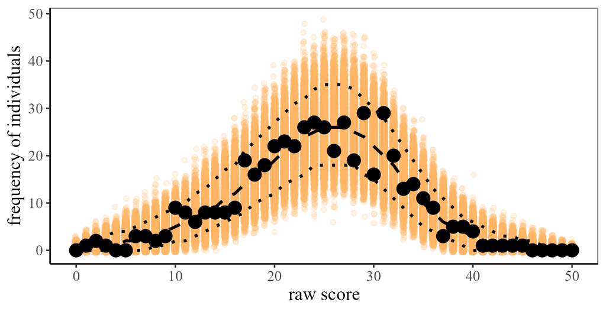

```r
NC_info <- raw_score_ppc(fit_info = info)
visual_raw_score_ppc(NC_info)
```

The observed raw score distribution appears to be well represented by the fitted model. Most observed raw scores (black dots) lie within the 90% posterior predictive interval (dotted lines), and all observed values fall within the range of the posterior predictive distribution (indicated by the orange points). Together, these results suggest that the fitted model reproduces the observed raw score distribution well.

To assess model fit across the full age range of the target population, the same evaluation should also be performed separately for different age groups. This can be accomplished using the `raw_score_ppc()` function with the `age_range` argument. The NC statistics are then computed and visualized separately for the specified age groups.

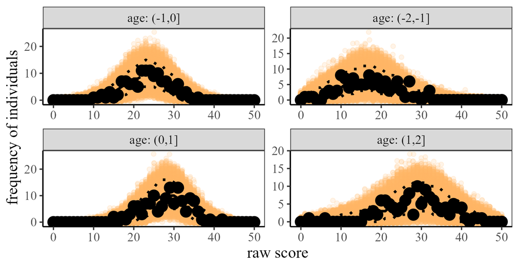

```r
NC_info_age <- raw_score_ppc(fit_info = info,
                      age_range = seq(-2,2,1))
visual_raw_score_ppc(NC_info_age)
```

The model appears to provide a good fit across all age groups, as the observed raw score distributions are consistent with those implied by the fitted model.

To evaluate model fit in greater detail, the agreement between the observed and model-implied item and person properties can be examined. The `item_person_fit()` function compares the observed and model-implied numbers of correct responses per person and responses per item.

We first evaluate the item fit.

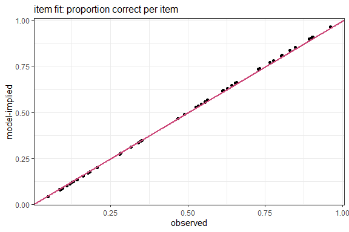

```r
item_person_fit(fit_info =info, parameter = "item")
```

The observed and model-implied frequencies are in close agreement, indicating that the estimated item parameters adequately describe the observed data.

Further it is assumed that items are conditionally independent. To check if this assumption holds the item residual correlation matrix can be evaluated using

```r
item_residual_cor(fit_info = info)
```

```
#>     Min.  1st Qu.   Median     Mean  3rd Qu.     Max.
#> -0.18830 -0.04377 -0.01201 -0.01364  0.01850  0.14197
```

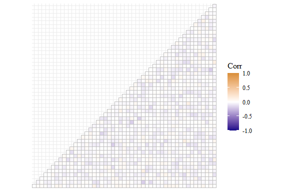

This shows that the correlation between the item residuals are low and do not exceed a correlation above 0.2. We therefore conclude that the item independence assumption is met.

Next, we evaluate the person-level fit.

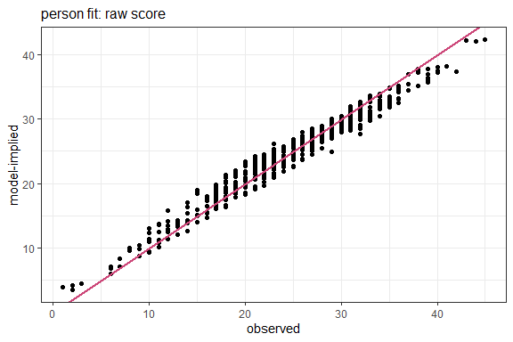

```r
item_person_fit(fit_info =info, parameter = "person")
```

The observed and model-implied frequencies are in close agreement. A slight systematic pattern is visible, however: for high-performing individuals, the model tends to predict a slightly lower number of correct responses than observed, whereas the opposite is true for low-performing individuals. This regression towards the mean is usually observed in Bayesian IRT models because observed scores are slightly shrunk towards the prior mean. The more informative a test, the smaller this effect. This pattern does not indicate poor model fit, but it is important to be aware of it when interpreting the results.

To explore, whether the model implied norm scores align well with the estimated latent trait distribution in the normative sample, the estimated latent trait estimates across age can be compared to the estimated model-implied quantile curves. Because this plot compares different aspects of the model, it provides insight into the model’s internal consistency and into how the latent trait distribution varies with age. For a well-fitting model, the plot should show no signs of inconsistency. However, the absence of inconsistencies does not, by itself, guarantee good overall model fit.

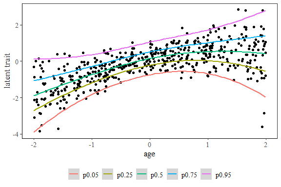

```r
quantile_curves(fit_info = info,
                probs = c(0.05, 0.25, 0.5, 0.75, 0.95))
```

The model-implied quantile curves closely follow the estimated latent trait values, indicating that the fitted model is internally consistent.

A further consistency check is to examine the distribution of the normed latent traits within age groups. The model assumes that the normed latent trait follows a standard normal distribution. To assess whether this assumption is satisfied, the `normscore_dist()` function plots a histogram of the estimated normed latent traits together with the density of the standard normal distribution for each age group.

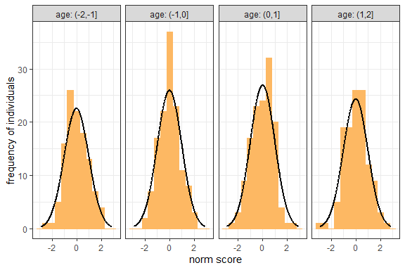

```r
normscore_dist(fit_info= info, age_range = seq(-2,2,1), binwidth = 0.5)
```

In this example, the distributions of the normed latent traits appear approximately normal across all age groups, providing further support for the internal consistency of the fitted model.

A final consistency check is to examine how the mean and standard deviation of the latent trait distribution vary with age. The estimated trajectories can then be evaluated in light of substantive or theoretical expectations to determine whether the age-related changes implied by the model are plausible.

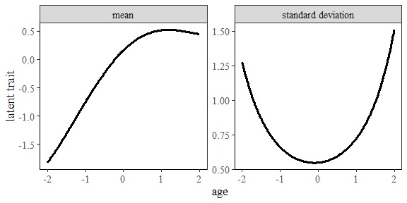

```r
effect_age(fit_info = info)
```

The estimated age effects closely resemble those used to generate the data, suggesting that the fitted model captures the underlying relationship between age and the latent trait well.

## 4. Norm new individuals

Suppose a new individual has the item response pattern `y` and age `age`.

```r
y <-  c(1,1,0,0,1,0,1,1,0,0,1,0,0,1,1,0,0,1,1,0,1,1,1,0,1,0,1,1,1,1,1,1,0,0,0,
        1,0,1,1,0,0,0,0,1,1,1,0,1,0,0)
age <- -1
```

To obtain a norm score for a new individual, the fitted IRT norming model is applied using the posterior draws of the item parameters and the latent trait distribution obtained during model fitting. Only the individual’s latent trait is estimated; all other model parameters remain fixed at their previously estimated posterior draws.

The individual’s norm score is then obtained by evaluating the estimated latent trait relative to the corresponding latent trait distribution in the reference population. Thus, the new individual’s data are used only to estimate their latent trait. The fitted model itself is not updated, and no model parameters are re-estimated.

```r
info_newperson <- norm_new_individual(new_y = y, new_age= age,
                                     fit_info = info)
# information about the norm score estimate of the individuals norm score
info_newperson$summary
```

```
#> $mean
#> [1] 0.9399413
#>
#> $sd
#> [1] 0.4818565
#>
#> $median
#> [1] 0.9366068
#>
#> $ci
#>         2.5%        97.5%
#> 0.0006555537 1.8933113084
```

Our best estimate of the individual’s latent trait is 0.939, corresponding to a score approximately 0.9 standard deviations above the average for individuals of the same age. The 95% credible interval for the individual’s norm score ranges from 0.001 to 1.893. Thus, the individual is likely to perform above the average level, but there is limited evidence that the individual’s ability is exceptionally high.

American Educational Research Association. 2014. *Standards for Educational and Psychological Testing*. American Educational Research Association.

Grob, Alexander, Priska Hagmann-von Arx, Selma Ruiter, Marieke Timmerman, and Linda Visser. 2018. *IDS-2: Intelligentie-En Ontwikkelingsschalen Voor Kinderen En Jongeren*. Hogrefe Publishing.

Heister, Hannah M, Casper J Albers, Marie Wiberg, and Marieke E Timmerman. 2024. “Item Response Theory-Based Continuous Test Norming.” *Psychological Methods*. https://doi.org/10.1037/met0000686.

Vehtari, Aki, Jonah Gabry, Måns Magnusson, Yuling Yao, Paul-Christian Bürkner, Topi Paananen, and Andrew Gelman. 2026. *Loo: Efficient Leave-One-Out Cross-Validation and WAIC for Bayesian Models*. https://mc-stan.org/loo/.